# Welcome to Santa Barbara Data Day!

## Challenge: Changing the `shape` of points

To make our previous plot even easier to read, let’s make each species have a different shape in the plot. For this, use the `shape` argument inside the `aes()` function.

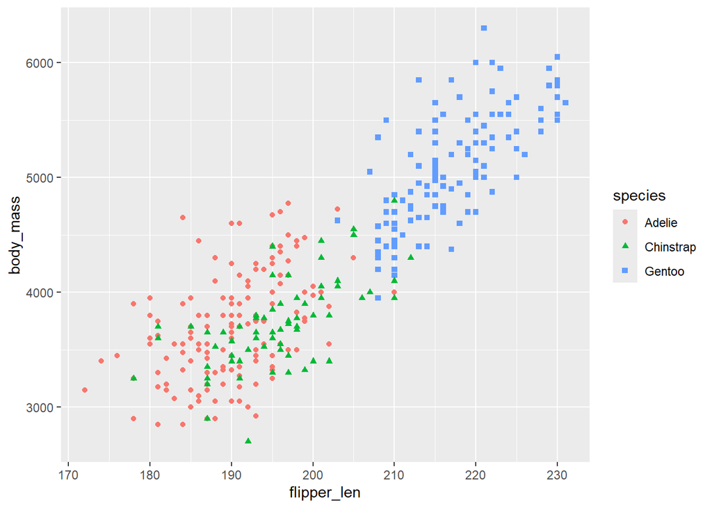

```r
# Solution
ggplot(data = penguins_clean, mapping = aes(x = flipper_len, y = body_mass, color = species, shape = species)) +
  geom_point()
```

## Using bar plots

All ggplots will follow the structure we just used: call `ggplot()`, specify the mapping of variables with `aes()`, and the plot type we want with a given `geom_*()`.

Let’s do now a bar plot, counting the number of penguins in each island. This is straightforward, using `geom_bar` as our geometry.

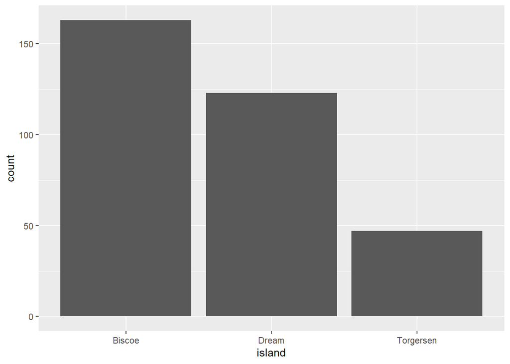

```r
ggplot(data = penguins_clean, mapping = aes(x = island)) +
  geom_bar()
```

To give a more professional look to our plot, we can modify the axis labels and add a title using the `labs()` function, like this:

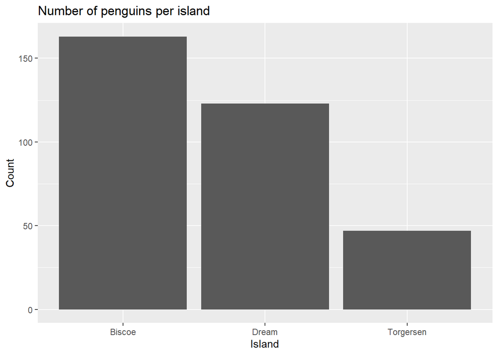

```r
ggplot(data = penguins_clean, mapping = aes(x = island)) +
  geom_bar() +
  labs(title = "Number of penguins per island",
       x = "Island",
       y = "Count")
```

## Challenge: Make your own plot

Using the penguins dataset, make your own plot. Look at the cheatsheet or the Graph Gallery for inspiration. To give you a couple of ideas, try a histogram or a box plot. Or add another variable to our previous scatter and bar plots.

If you are up for a harder challenge, look into faceting, here is an example:

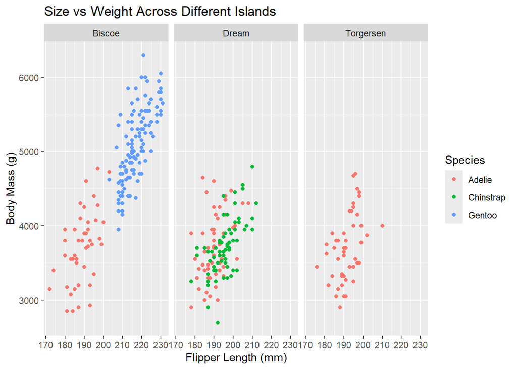

```r
ggplot(penguins_clean, aes(x = flipper_len, y = body_mass, color = species)) +
  geom_point() +
  facet_wrap(~island) +
  labs(title = "Size vs Weight Across Different Islands",
       x = "Flipper Length (mm)",
       y = "Body Mass (g)",
       color = "Species")
```

# 5. Loading data

Previously we used the `data()` function to load the penguins dataset, we could do that as it came built into R. But in more real-life scenarios, you’ll need to read data from a file you have in your computer, maybe an Excel spreadsheet or a CSV (comma-separated values) file.

To show this, we’ll download data from Gapminder, a non-profit that gathers data on countries around the world. Follow these steps:

1. Visit https://www.gapminder.org/data/ and download to your computer the CSV data for Life expectancy at birth.
2. Move this data inside your RStudio project. If you are using Posit Cloud, go to the Files pane, click ‘Upload’, and select the file from your computer’s download folder. If you are using a local installation of RStudio, move the file to the project folder you are working on.
3. Create a new script file, and at the top run `library(tidyverse)`.
4. Use the `read_csv()` function, giving the path to the file as the argument, like this

```r
lex <- read_csv("lex.csv")
```

Note: If you want to read an Excel (XLS or XLSX) file instead, load `library(readxl)` also and use the `read_excel` function.

# 6. Markdown and Quarto

You might be wondering: How did we make this website that has text, R code, and plots all in one place? We used Markdown and Quarto.

To show you this, let’s create a new Quarto document by clicking File > New File > Quarto Document. Give your document a title, keep the other default options, and click Create.

## What is Markdown?

Markdown is a way to write a document using plain text. You can open a Markdown file on any computer, without needing a specialized application or the internet, unlike Google Docs, Microsoft Word, or PDFs.

It uses specific syntax (special characters) to add styling to text instead of making you click formatting buttons in an application toolbar.

Basic Markdown Syntax

Here is how you format text in Markdown:

Headers:

```
# Biggest Header

## Second Biggest Header

### Third Biggest Header
```

Text Styles:

```
*This text will be italicized* **This text will be bold**
```

Lists:

```
-   Item 1
-   Item 2
    -   Sub-item A
```

## What is Quarto?

Quarto is the engine that takes your Markdown file and “renders” it. It runs the R code, creates the graphs, and weaves everything into a beautiful final document (like this HTML page, a PDF, or even a presentation).

This is a core skill in Reproducible Research: If your data changes tomorrow, you just click Render, and your entire report updates automatically!

# Appendix

Here, some plot examples with the penguins dataset

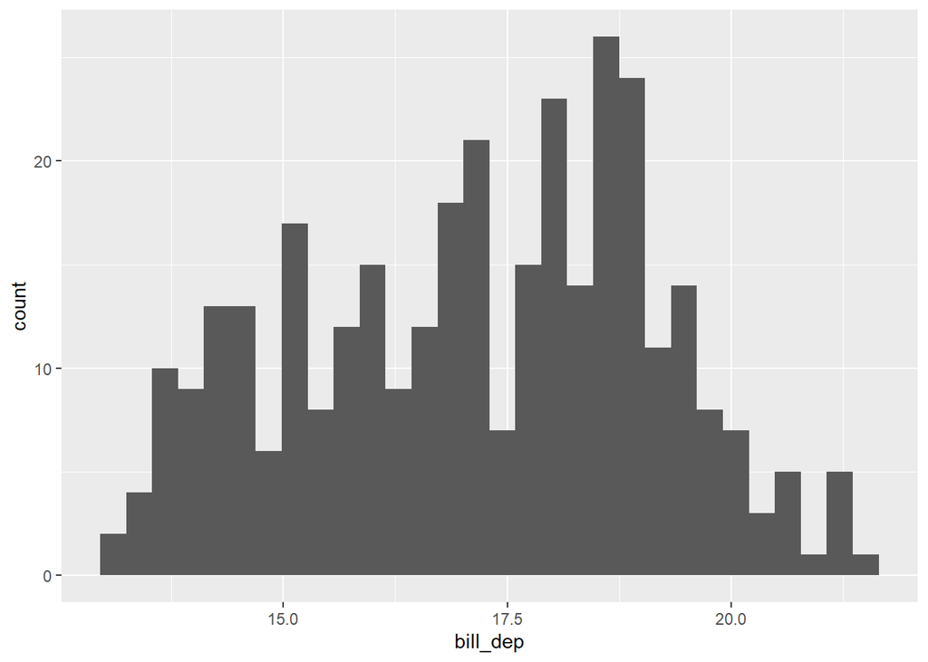

```r
# Histogram showing the distribution of bill depth
ggplot(data = penguins_clean, mapping = aes(x = bill_dep)) +
  geom_histogram()
```

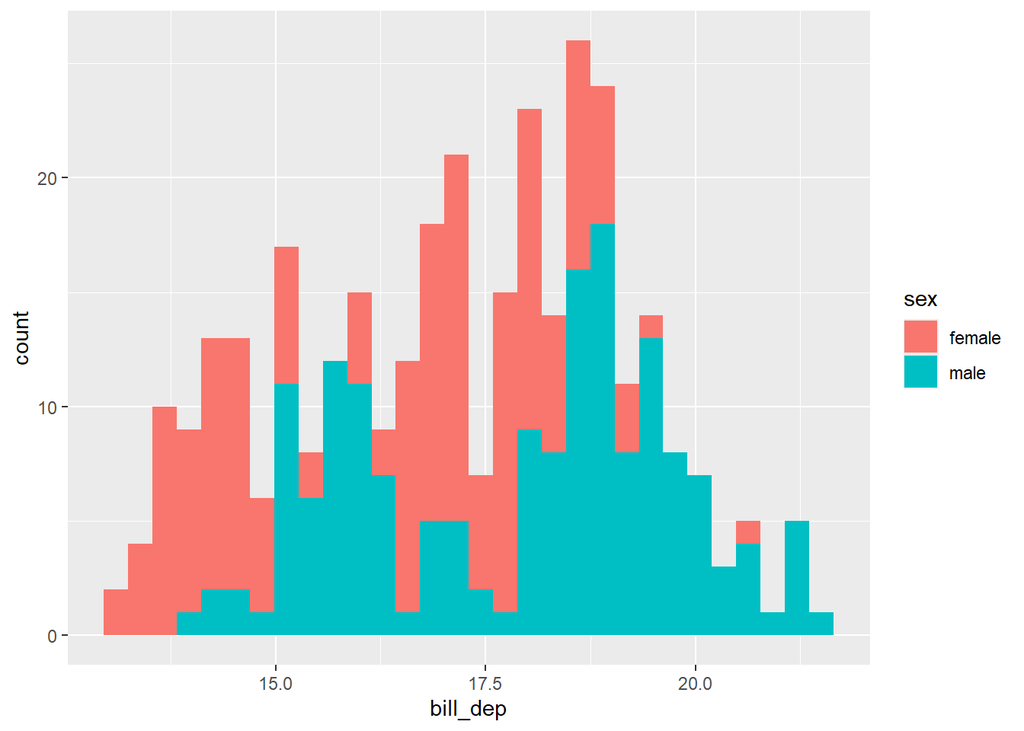

```r
# Histogram showing the distribution of bill depth, by sex
ggplot(data = penguins_clean, mapping = aes(x = bill_dep, fill = sex)) +
  geom_histogram()
```

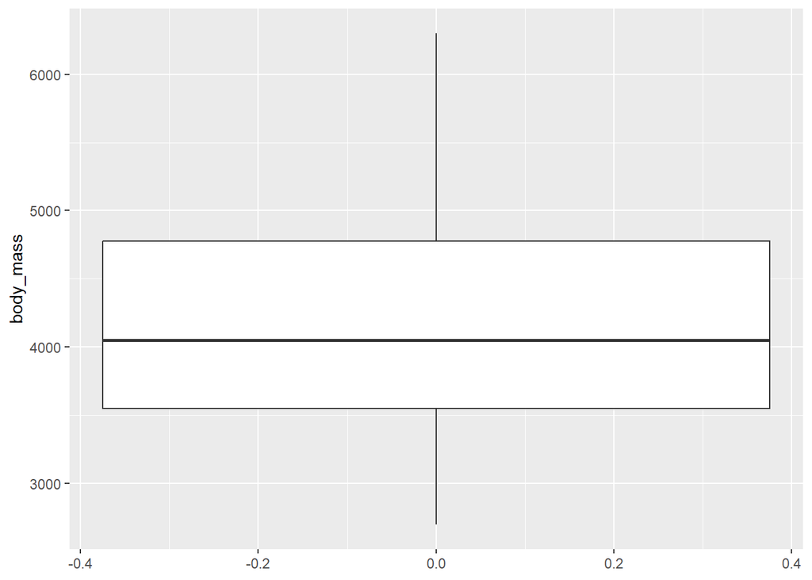

```r
# Box plot showing the distribution of body mass
ggplot(data = penguins_clean, mapping = aes(y = body_mass)) +
  geom_boxplot()
```

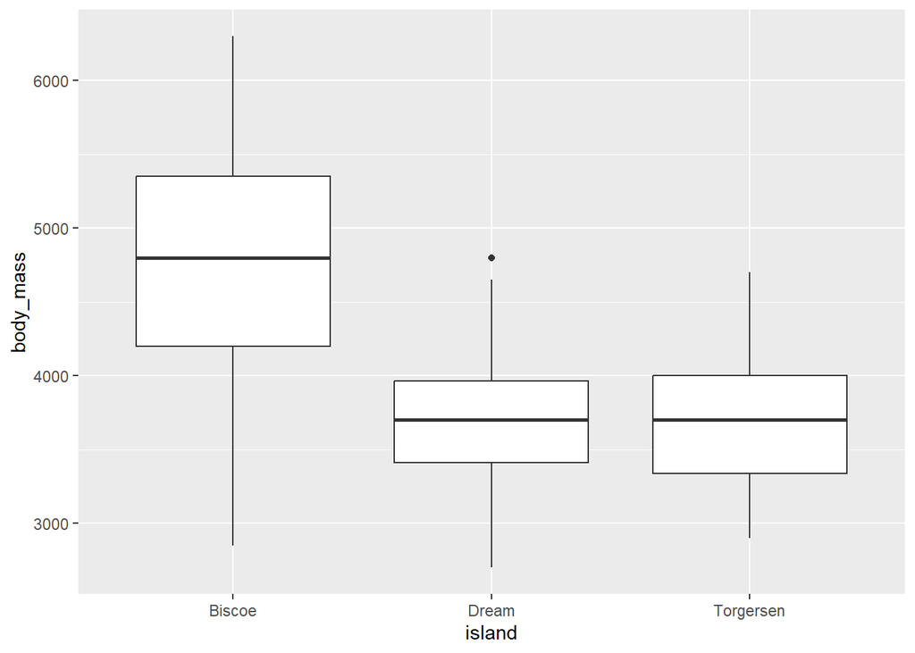

```r
# Box plot showing the distribution of body mass, per island
ggplot(data = penguins_clean, mapping = aes(x = island, y = body_mass)) +
  geom_boxplot()
```